# import

2022-09-26

## load Packages

```r
library(data.table)
library(tidyverse)
library(lubridate)
library(rai)
library(caret)
```

# Import data

## Thoughts

Do we need a lag? Meaning: are google trends coming into account later (for sure, but whats the timespan)? Can we measure this? If so, how?

## Assignment

Number of nights spent at tourist accommodation establishments (Eurobase code: TOUR_OCC_NIM, UNIT:NR, NACE R2: I551-I553, INDIC TO: B006)

In case there is no available reference to INDIC TO: B006 in the data, use the following setting: TOUR_OCC_NIM, UNIT:NR, NACE R2:I1551-I1553, TOTAL.

The published figures are available here - and the task of each team is to nowcast the values of this monthly indicator for September 2022 until April 2023.

In this phase, each team submits nowcasts (according to the approaches that they have developed) for the number of tourism nights spent at tourist accommodation establishments (tourism) indicator. The team can make up to 5 different entries, using different approaches. For each entry, nowcasts (in the form of point estimates) must be submitted for *at least 5 countries* (chosen by the team) for a given month. (For example, if the current reference period is September 2022, the teams will have to provide the point estimates for 5 or more countries to have a valid entry for September 2022.) For an entry to be considered in the evaluation phase, there must be *at least 6 consecutive monthly submissions* for each of at least 5 countries. Each monthly submission of an entry needs to be accompanied by a brief description of the approach used.

## Indicators

```r
datapath = "../data/"
ind_path = paste0(datapath, "indicators/")
list.files(ind_path)
```

```
## [1] "tour_occ_nim_custom.csv"     "tour_occ_nim_linear_all.csv"
```

```r
ind_in = fread(paste0(ind_path,"tour_occ_nim_custom.csv"))

ind_t1 = ind_in[,-c(1:3)] %>%
  as_tibble() %>%
  mutate(month_end = as_date(paste0(TIME_PERIOD,"-01")),.before=1)

ind_t1 %>% select(nace_r2) %>% distinct()
```

```
## # A tibble: 2 × 1
##   nace_r2
##   <chr>
## 1 I551-I553
## 2 I552_I553
```

```r
## Scale
scale2 <- function(x, na.rm = FALSE) (x - mean(x, na.rm = na.rm)) / sd(x, na.rm)

ind_de= ind_t1 %>%
  filter(geo == "DE" & nace_r2 == "I551-I553" & unit=="NR" & c_resid=="TOTAL") %>%
  mutate(obs_value_std = scale2(OBS_VALUE),
         obs_value_norm = (OBS_VALUE-mean(OBS_VALUE))/max(abs(OBS_VALUE-mean(OBS_VALUE))),
         obs_value_max = OBS_VALUE/max(OBS_VALUE)
         )

ind_stats = ind_de %>%
  summarise(mean=mean(OBS_VALUE),
            sd=sd(OBS_VALUE),
            max=max(OBS_VALUE),
            norm=max(abs(OBS_VALUE-mean(OBS_VALUE)))
            )
```

Therefore, the stats are:

```r
ind_stats
```

```
## # A tibble: 1 × 4
##        mean        sd      max      norm
##       <dbl>     <dbl>    <int>     <dbl>
## 1 26941107. 10327635. 53511362 26570255.
```

## Google Trends

```r
goo_path = paste0(datapath, "googleTrends/")
list.files(goo_path)
```

```
##  [1] "Belgium1.csv"                 "Bulgaria1.csv"
##  [3] "Czech1.csv"                   "Denmark1.csv"
##  [5] "europa_de_week.csv"           "europa_world_week.csv"
##  [7] "Germany_germany_weekly.csv"   "Germany_worldwide_weekly.csv"
##  [9] "Germany1.csv"                 "Germany1_full.csv"
## [11] "Germany1_weekly.csv"          "Germany1_yearly.csv"
## [13] "SearchGermany1.csv"
```

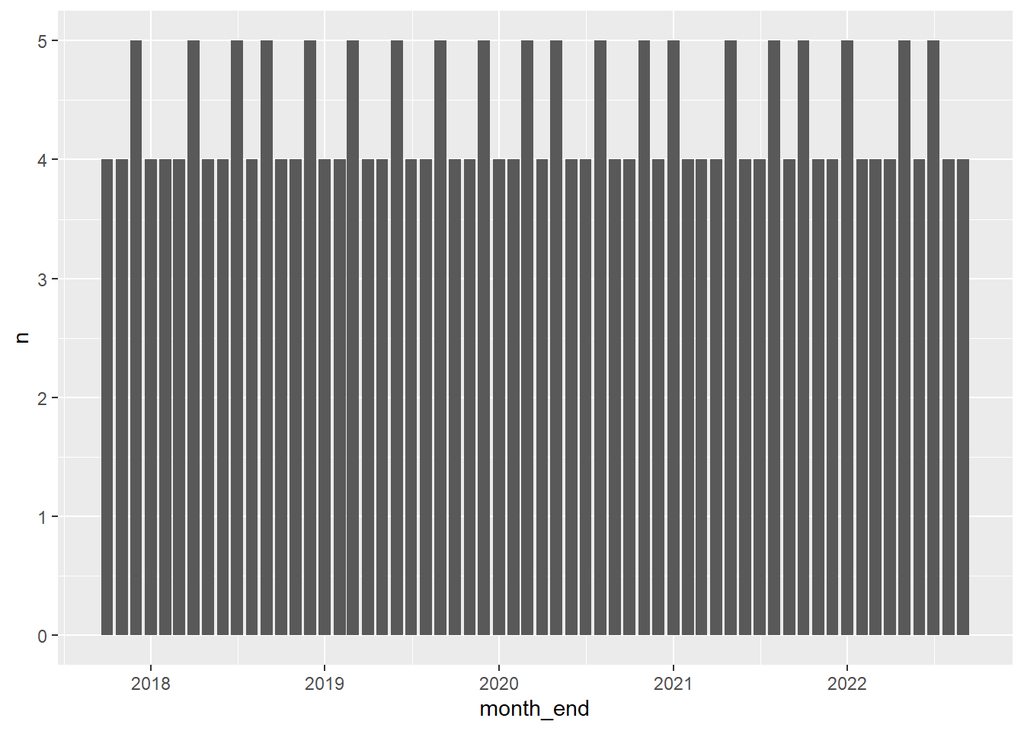

```r
series = c("europa_de_week.csv", "europa_world_week.csv", "Germany_germany_weekly.csv", "Germany_worldwide_weekly.csv", "SearchGermany1.csv")
input = paste0(goo_path, series)
in_list =input %>% map(~fread(., skip=2))
in_list = map(in_list, as_tibble)

df = reduce(.x = in_list, .f = full_join)
div_100 = function(x) (x/100)
df = df %>% mutate(across(.cols = 2:6, scale2))

df_cl = df %>%
   rename(eur_world=`europa: (Weltweit)`,
          eur_de=`europa: (Deutschland)`,
          de_de=`deutschland: (Deutschland)`,
          de_world=`deutschland: (Weltweit)`,
          tourism_de=`tourism: (Deutschland)`
          ) %>%
  mutate(week_end = Woche + 7, .before=2) %>%
  mutate(month_end = floor_date(week_end, unit="month"), .before=3)

month_cnt = df_cl %>% select(month_end) %>% group_by(month_end) %>% summarise(n=n())
ggplot(data=month_cnt, aes(x=month_end, y=n)) +
  geom_col()
```

For now, this looks fine. To do if accuracy needs a boost: Divide overlapping weeks proportional into both neighbouring regions.

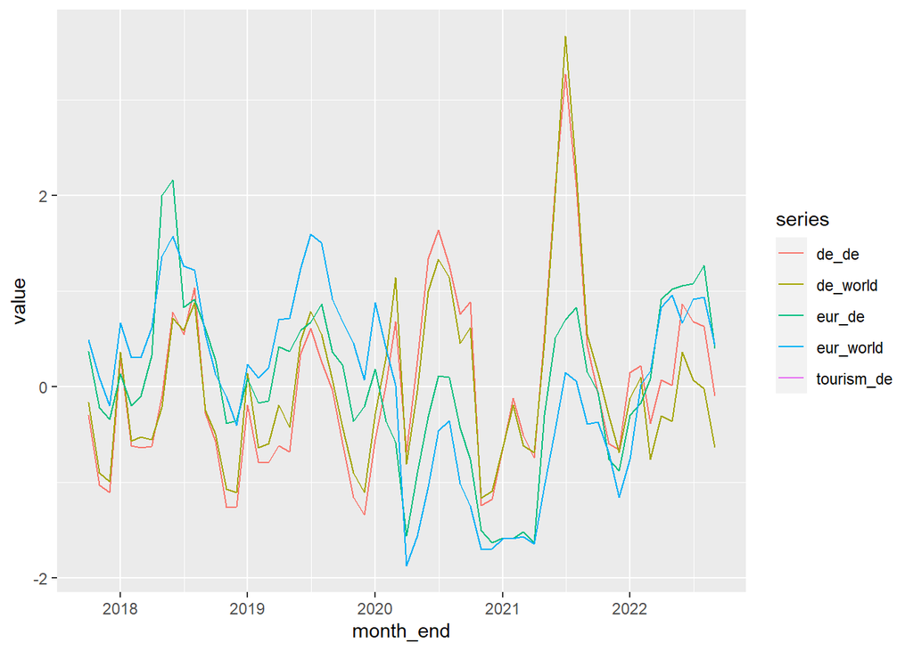

```r
df_cl_month = df_cl %>%
  select(!week_end) %>%
  group_by(month_end) %>%
  summarise(across(.cols = 2:6, mean))

df_cl_month %>%
  gather(key=series, value=value,-month_end) %>%
  ggplot(aes(x=month_end, y=value, color=series)) +
  geom_line()
```

# Combine data

```r
df_de = ind_de[,-c(2:6,8)] %>%
  full_join(df_cl_month, by="month_end") %>%
  filter(month_end > as_date("2017-09-01"))

theResponse=df_de$obs_value_std[-c(59:60)]
theData = df_de[-c(59:60),6:9]
```

# Test

## LM

```r
lm1 = lm(obs_value_std  ~ eur_de+eur_world+de_de+de_world, data=df_de)
summary(lm1)
```

```
##
## Call:
## lm(formula = obs_value_std ~ eur_de + eur_world + de_de + de_world,
##     data = df_de)
##
## Residuals:
##      Min       1Q   Median       3Q      Max
## -1.58485 -0.39583  0.06396  0.55155  1.37441
##
## Coefficients:
##             Estimate Std. Error t value Pr(>|t|)
## (Intercept)   0.2307     0.1004   2.297   0.0256 *
## eur_de        0.7253     0.3505   2.070   0.0434 *
## eur_world     0.5164     0.2898   1.782   0.0805 .
## de_de         0.1579     0.5223   0.302   0.7637
## de_world      0.1871     0.4992   0.375   0.7093
## ---
## Signif. codes:  0 '***' 0.001 '**' 0.01 '*' 0.05 '.' 0.1 ' ' 1
##
## Residual standard error: 0.7615 on 53 degrees of freedom
##   (2 Beobachtungen als fehlend gelöscht)
## Multiple R-squared:  0.7293, Adjusted R-squared:  0.7089
## F-statistic:  35.7 on 4 and 53 DF,  p-value: 1.854e-14
```

```r
mod_lm =caret::train(x=theData, y=theResponse, method="lm")
lm2 = lm(obs_value_std  ~ eur_de+eur_world+de_de, data=df_de)
summary(lm2)
```

```
##
## Call:
## lm(formula = obs_value_std ~ eur_de + eur_world + de_de, data = df_de)
##
## Residuals:
##      Min       1Q   Median       3Q      Max
## -1.53798 -0.40488  0.06241  0.56024  1.34105
##
## Coefficients:
##             Estimate Std. Error t value Pr(>|t|)
## (Intercept)  0.23387    0.09928   2.356   0.0221 *
## eur_de       0.66834    0.31327   2.133   0.0374 *
## eur_world    0.56803    0.25291   2.246   0.0288 *
## de_de        0.34660    0.13771   2.517   0.0148 *
## ---
## Signif. codes:  0 '***' 0.001 '**' 0.01 '*' 0.05 '.' 0.1 ' ' 1
##
## Residual standard error: 0.7554 on 54 degrees of freedom
##   (2 Beobachtungen als fehlend gelöscht)
## Multiple R-squared:  0.7286, Adjusted R-squared:  0.7135
## F-statistic: 48.32 on 3 and 54 DF,  p-value: 2.603e-15
```

We do need more data! Seems that google trends monthly data should be sufficient!

## RAI

```r
#rai_out = rai(theData, theResponse)
#summary(rai_out$model)
```

## Bayesian reg NN

```r
theData = as.data.frame(theData)
fitControl <- caret::trainControl(method = "repeatedcv",
                            number = 5, ## 5-fold CV...
                            repeats = 5)  ## repeated 5 times
mod_brnn =caret::train(x=theData, y=theResponse, method="brnn", trControl = fitControl, verbose=F)
```

[output not shown]

[output cut: 249 more lines]

[output not shown]

```r
mod_brnn
```

```
## Bayesian Regularized Neural Networks
##
## 58 samples
##  4 predictor
##
## No pre-processing
## Resampling: Cross-Validated (5 fold, repeated 5 times)
## Summary of sample sizes: 47, 46, 46, 46, 47, 47, ...
## Resampling results across tuning parameters:
##
##   neurons  RMSE       Rsquared   MAE
##   1        0.7576938  0.7232748  0.6243438
##   2        0.7826652  0.7037055  0.6227509
##   3        0.8048325  0.6942746  0.6353192
##
## RMSE was used to select the optimal model using the smallest value.
## The final value used for the model was neurons = 1.
```

```r
predict(mod_brnn, df_de[c(59:60),6:9])
```

```
## [1] 1.9040772 0.7825704
```

## Deep Autoencoder (not working)

```r
fitControl <- caret::trainControl(method = "repeatedcv",
                            number = 5, ## 5-fold CV...
                            repeats = 5)  ## repeated 5 times
mod_nn =caret::train(x=theData, y=theResponse, method="dnn", trControl = fitControl, verbose=F)
```

```r
mod_nn
predict(mod_nn, df_de[c(59:60),6:9])
```

## GBM

```r
gbmGrid <-  expand.grid(interaction.depth = c(1:4),
                        n.trees = (1:50),
                        shrinkage = 0.1,
                        n.minobsinnode = 5)

fitControl <- caret::trainControl(method = "repeatedcv",
                            number = 5, ## 5-fold CV...
                            repeats = 10)  ## repeated 5 times
mod_gbm =caret::train(x=theData, y=theResponse, method="gbm", trControl = fitControl, tuneGrid=gbmGrid, verbose=F)
```

```r
#mod_gbm
mod_gbm$bestTune
```

```
##    n.trees interaction.depth shrinkage n.minobsinnode
## 45      45                 1       0.1              5
```

```r
mod_gbm$results %>% filter(n.trees==33 & interaction.depth==1 & shrinkage == 0.1 & n.minobsinnode==5)
```

```
##   shrinkage interaction.depth n.minobsinnode n.trees      RMSE Rsquared
## 1       0.1                 1              5      33 0.8051433 0.684183
##         MAE    RMSESD RsquaredSD    MAESD
## 1 0.6544048 0.1484321  0.1485139 0.121853
```

```r
summary(mod_gbm)
```

[output not shown]

```r
predict(mod_gbm, df_de[c(59:60),6:9])
```

```
## [1] 1.6233498 0.7646274
```

## SVN

http://topepo.github.io/caret/train-models-by-tag.html#support-vector-machines

Die sehen sehr vielversprechend aus! Das sollte man weiter verfolgen.

```r
fitControl <- caret::trainControl(method = "repeatedcv",
                            number = 5, ## 5-fold CV...
                            repeats = 5)  ## repeated 5 times
mod_svn =caret::train(x=theData, y=theResponse, method="svmRadialSigma", trControl = fitControl, verbose=F)
```

```r
mod_svn
```

```
## Support Vector Machines with Radial Basis Function Kernel
##
## 58 samples
##  4 predictor
##
## No pre-processing
## Resampling: Cross-Validated (5 fold, repeated 5 times)
## Summary of sample sizes: 47, 46, 46, 47, 46, 46, ...
## Resampling results across tuning parameters:
##
##   sigma      C     RMSE       Rsquared   MAE
##   0.0460774  0.25  0.8527645  0.7262716  0.7290191
##   0.0460774  0.50  0.7526553  0.7309018  0.6172500
##   0.0460774  1.00  0.7474971  0.7289656  0.5855725
##   0.3140855  0.25  0.8545449  0.6745909  0.7072742
##   0.3140855  0.50  0.8182059  0.6699988  0.6441572
##   0.3140855  1.00  0.8401664  0.6544772  0.6385592
##   0.5820937  0.25  0.9018744  0.6494764  0.7487043
##   0.5820937  0.50  0.8619865  0.6358371  0.6746226
##   0.5820937  1.00  0.8915763  0.6116609  0.6700496
##
## RMSE was used to select the optimal model using the smallest value.
## The final values used for the model were sigma = 0.0460774 and C = 1.
```

```r
summary(mod_svn)
```

```
## Length  Class   Mode
##      1   ksvm     S4
```

```r
predict(mod_svn, df_de[c(59:60),6:9])
```

```
## [1] 1.6209961 0.6483803
```

# Compare results:

```r
res_tab = tibble(
  lm = predict(mod_lm,df_de[c(59:60),6:9]),
  brnn = predict(mod_brnn, df_de[c(59:60),6:9]),
  gbm = predict(mod_gbm, df_de[c(59:60),6:9]),
  svn = predict(mod_svn, df_de[c(59:60),6:9])
)

res_stats = as_tibble(getTrainPerf(mod_lm)) %>%
  add_row(getTrainPerf(mod_brnn)) %>%
  add_row(getTrainPerf(mod_gbm)) %>%
  add_row(getTrainPerf(mod_svn))

res_tab
```

```
## # A tibble: 2 × 4
##      lm  brnn   gbm   svn
##   <dbl> <dbl> <dbl> <dbl>
## 1 1.72  1.90  1.62  1.62
## 2 0.600 0.783 0.765 0.648
```

```r
res_stats
```

```
## # A tibble: 4 × 4
##   TrainRMSE TrainRsquared TrainMAE method
##       <dbl>         <dbl>    <dbl> <chr>
## 1     0.856         0.657    0.667 lm
## 2     0.758         0.723    0.624 brnn
## 3     0.800         0.687    0.638 gbm
## 4     0.747         0.729    0.586 svmRadialSigma
```

Last but not least: Variable importance:

```r
varImp(mod_svn)
```

```
## loess r-squared variable importance
##
##           Overall
## eur_de    100.000
## eur_world  77.974
## de_world    7.535
## de_de       0.000
```

Die Suchen nach Europa (Kategorie Reisen) in Deutschland und der Welt haben wohl den größten Einfluss für die Übernachtungen in Deutschland.